# Problem Statement

# Data Exploration

This dataset is a slightly modified version of the imagenette 320 px dataset from fastai. This contains 10 classes: cassetePlayer, ChainShaw, Church, EnglishSpringer, FrenchHorn, GarbageTruck, GasPump, GolfBall, parachute, tench.

##### pre-work

this step, we retrieve data from the path, then specify the size and batch, to settle down three datasets: train,validation, test.

```python
train_dataset_path = '/kaggle/input/imagenettetvt320/train'
validation_dataset_path = '/kaggle/input/imagenettetvt320/val'
test_dataset_path ='/kaggle/input/imagenettetvt320/test'
```

```python
train_data= tf.keras.preprocessing.image_dataset_from_directory(directory=train_dataset_path,
                                                                            image_size=(224,224),
                                                                           label_mode="categorical",
                                                                            batch_size=32)
valid_data = tf.keras.preprocessing.image_dataset_from_directory(directory=validation_dataset_path,
                                                                            image_size=(224,224),
                                                                          label_mode="categorical",
                                                                            batch_size=32)
test_data = tf.keras.preprocessing.image_dataset_from_directory(directory=test_dataset_path,
                                                                            image_size=(224,224),
                                                                          label_mode="categorical",
                                                                            batch_size=32)
```

```
Found 9469 files belonging to 10 classes.
Found 1309 files belonging to 10 classes.
Found 2616 files belonging to 10 classes.
```

##### data preprocess

The reason we do so, is that we want to look at how the data looks like(how many classes, how many records). We only choose train dataset as a representation to have a glance.

```python
# above output tells us that in this train_dataset, totally 10 classes and 9469 images.
# batch size is 32, means that each time retrive 32 images.


for data_batch, labels_batch in train_data:
    print("data batch shape:", data_batch.shape)
    print("labels batch shape:", labels_batch.shape)
    break
```

```
data batch shape: (32, 224, 224, 3)
labels batch shape: (32, 10)
```

##### how many classes there are

```python
for label in labels_batch:
    print(label)


#match above: 10 classes
```

```
tf.Tensor([0. 0. 0. 0. 0. 0. 0. 0. 1. 0.], shape=(10,), dtype=float32)
tf.Tensor([0. 0. 0. 0. 0. 1. 0. 0. 0. 0.], shape=(10,), dtype=float32)
tf.Tensor([0. 0. 0. 0. 0. 0. 1. 0. 0. 0.], shape=(10,), dtype=float32)
tf.Tensor([0. 0. 0. 0. 0. 0. 0. 0. 0. 1.], shape=(10,), dtype=float32)
tf.Tensor([0. 0. 0. 0. 0. 0. 1. 0. 0. 0.], shape=(10,), dtype=float32)
tf.Tensor([0. 0. 1. 0. 0. 0. 0. 0. 0. 0.], shape=(10,), dtype=float32)
tf.Tensor([0. 0. 0. 0. 0. 0. 0. 0. 1. 0.], shape=(10,), dtype=float32)
tf.Tensor([1. 0. 0. 0. 0. 0. 0. 0. 0. 0.], shape=(10,), dtype=float32)
tf.Tensor([0. 0. 0. 0. 0. 1. 0. 0. 0. 0.], shape=(10,), dtype=float32)
tf.Tensor([0. 0. 0. 1. 0. 0. 0. 0. 0. 0.], shape=(10,), dtype=float32)
tf.Tensor([0. 0. 0. 0. 0. 0. 0. 0. 0. 1.], shape=(10,), dtype=float32)
tf.Tensor([0. 0. 0. 0. 0. 0. 0. 0. 0. 1.], shape=(10,), dtype=float32)
tf.Tensor([0. 0. 0. 0. 1. 0. 0. 0. 0. 0.], shape=(10,), dtype=float32)
tf.Tensor([0. 0. 0. 0. 1. 0. 0. 0. 0. 0.], shape=(10,), dtype=float32)
tf.Tensor([0. 0. 0. 0. 0. 1. 0. 0. 0. 0.], shape=(10,), dtype=float32)
tf.Tensor([0. 0. 0. 0. 0. 0. 0. 0. 1. 0.], shape=(10,), dtype=float32)
tf.Tensor([0. 1. 0. 0. 0. 0. 0. 0. 0. 0.], shape=(10,), dtype=float32)
tf.Tensor([1. 0. 0. 0. 0. 0. 0. 0. 0. 0.], shape=(10,), dtype=float32)
tf.Tensor([0. 0. 0. 0. 0. 0. 0. 0. 1. 0.], shape=(10,), dtype=float32)
tf.Tensor([0. 1. 0. 0. 0. 0. 0. 0. 0. 0.], shape=(10,), dtype=float32)
tf.Tensor([0. 0. 0. 0. 0. 1. 0. 0. 0. 0.], shape=(10,), dtype=float32)
tf.Tensor([0. 0. 0. 0. 0. 0. 1. 0. 0. 0.], shape=(10,), dtype=float32)
tf.Tensor([0. 0. 0. 0. 0. 0. 0. 0. 0. 1.], shape=(10,), dtype=float32)
tf.Tensor([0. 1. 0. 0. 0. 0. 0. 0. 0. 0.], shape=(10,), dtype=float32)
tf.Tensor([0. 0. 0. 1. 0. 0. 0. 0. 0. 0.], shape=(10,), dtype=float32)
tf.Tensor([0. 1. 0. 0. 0. 0. 0. 0. 0. 0.], shape=(10,), dtype=float32)
tf.Tensor([0. 0. 0. 0. 0. 0. 1. 0. 0. 0.], shape=(10,), dtype=float32)
tf.Tensor([0. 0. 0. 0. 0. 1. 0. 0. 0. 0.], shape=(10,), dtype=float32)
tf.Tensor([0. 0. 0. 0. 0. 0. 0. 1. 0. 0.], shape=(10,), dtype=float32)
tf.Tensor([0. 0. 0. 0. 0. 0. 1. 0. 0. 0.], shape=(10,), dtype=float32)
tf.Tensor([0. 0. 0. 0. 0. 1. 0. 0. 0. 0.], shape=(10,), dtype=float32)
tf.Tensor([0. 0. 0. 0. 0. 0. 0. 1. 0. 0.], shape=(10,), dtype=float32)
```

##### what do they look like

[figure not shown]

```python
from matplotlib import pyplot
import numpy as np
pyplot.imshow(np.array(data_batch[7],dtype=np.uint8))
```

# Initial CNN

we build a rough CNN first.

##### model building

simply conv, pool, flatten, fully conntect layers. Here we don't input data or compile, we just want to see the architecture.

```python
inputs = keras.Input(shape=(224, 224, 3))
x = layers.Conv2D(filters=30,kernel_size=3,strides=(3,3),activation="relu")(inputs)
x = layers.MaxPooling2D(pool_size=2)(x)
x = layers.Conv2D(filters=60,kernel_size=3,strides=(3,3),activation="relu")(x)
x = layers.MaxPooling2D(pool_size=2)(x)
x = layers.Flatten()(x)
outputs = layers.Dense(80, activation="relu")(x)
outputs = layers.Dense(50, activation="relu")(x)
outputs = layers.Dense(10, activation="softmax")(x)
m1 = keras.Model(inputs=inputs, outputs=outputs)
m1.summary()
```

```
Model: "model_14"
_________________________________________________________________
 Layer (type)                Output Shape              Param #
=================================================================
 input_37 (InputLayer)       [(None, 224, 224, 3)]     0

 conv2d_128 (Conv2D)         (None, 74, 74, 30)        840

 max_pooling2d_121 (MaxPooli  (None, 37, 37, 30)       0
 ng2D)

 conv2d_129 (Conv2D)         (None, 12, 12, 60)        16260

 max_pooling2d_122 (MaxPooli  (None, 6, 6, 60)         0
 ng2D)

 flatten_40 (Flatten)        (None, 2160)              0

 dense_89 (Dense)            (None, 10)                21610

=================================================================
Total params: 38,710
Trainable params: 38,710
Non-trainable params: 0
_________________________________________________________________
```

##### manual sumary of model

input:224,224,3

conv:(w-k+2p)/s+1=(224-3+2*0)/3+1=74,74,30

pool:(74-2)/2+1=37,37,30

conv: (37-3+2x0)/3+1=12,12,60

pool: (12-2)/2+1=6,6,60

flatten: 6x6x60=2160

##### summary of model

more visualized

[figure not shown]

```python
from tensorflow.keras.utils import plot_model
plot_model(model, to_file='model_class1.png', show_shapes=True)
```

##### model compile and fit

here we compile with loss and accuracy, finally plug in data.

```python
m1.compile(loss="categorical_crossentropy",
                optimizer="Adam",
                metrics=["accuracy"])

history=m1.fit(train_data,epochs=30,verbose=1,validation_data=valid_data)
```

##### Accuracy is kind of high. Might be overfitting.

##### verify if it is overfitting

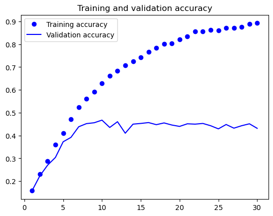

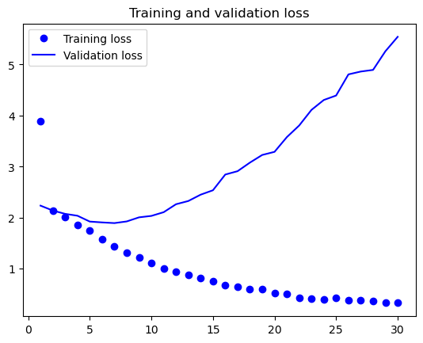

```python
import matplotlib.pyplot as plt
accuracy = history.history["accuracy"]
val_accuracy = history.history["val_accuracy"]
loss = history.history["loss"]
val_loss = history.history["val_loss"]
epochs = range(1, len(accuracy) + 1)
plt.plot(epochs, accuracy, "bo", label="Training accuracy")
plt.plot(epochs, val_accuracy, "b", label="Validation accuracy")
plt.title("Training and validation accuracy")
plt.legend()
plt.figure()
plt.plot(epochs, loss, "bo", label="Training loss")
plt.plot(epochs, val_loss, "b", label="Validation loss")
plt.title("Training and validation loss")
plt.legend()
plt.show()
```

##### from above: on validation dataset, accuracy stops improving at a point, and loss keeps increasing. And whether for accuracy or loss, from the score they always behave worse than train data.

##### test--make sure it is overfitting

```python
test_loss, test_acc=m1.evaluate(test_data_ImageNet320)
print(f"Test accuracy: {test_acc:.5f}")                                      #meets overfitting
```

```
Test accuracy: 0.45833
```

# Augmentation

we "zoom in" the data, as augmentation can help improve generalization--exposing data to a wider range of variations, such as changing orientation, flipping, rescale, lighting...

##### augmentation

```python
data_augmentation = keras.Sequential(
    [
        layers.RandomFlip("horizontal"),
        layers.RandomRotation(0.1),
        layers.RandomZoom(0.2),
        layers.RandomBrightness(factor=0.5),

    ]
)
```

*take a look at what it brings*

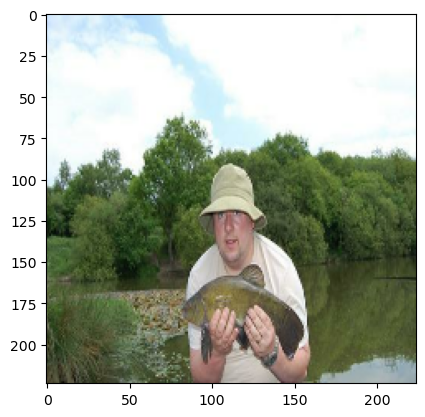

```python
pyplot.imshow(np.array(data_batch[10],dtype=np.uint8))
```

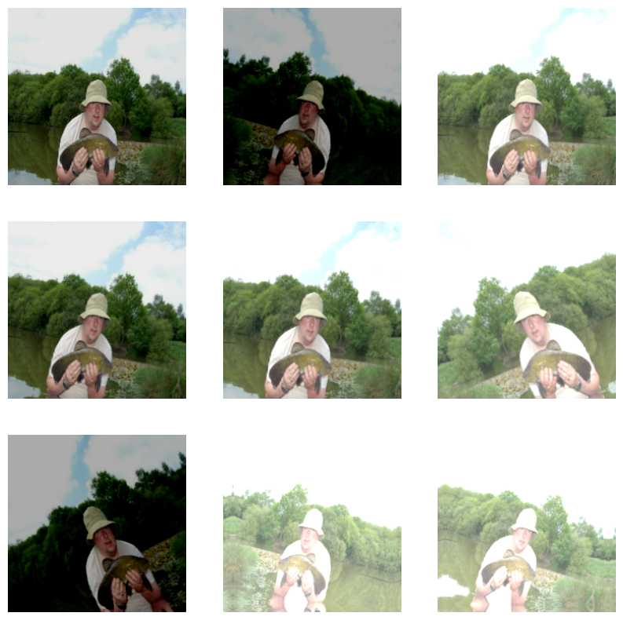

```python
plt.figure(figsize=(10, 10))
for images, _ in train_data.take(1):
    for i in range(9):
        augmented_images = data_augmentation(data_batch[10])
        ax = plt.subplot(3, 3, i + 1)
        plt.imshow(augmented_images.numpy().astype("uint8"))
        plt.axis("off")
```

```python
inputs = keras.Input(shape=(224, 224, 3))
x=data_augmentation(inputs)
```

##### rescale

```python
x = layers.Rescaling(1./255)(x)
```

##### change the rest too; also dropout to prevent overfitting

```python
x = layers.Conv2D(32, (3,3), activation = 'relu')(x)
x = layers.MaxPool2D(2,2)(x)
x = layers.Conv2D(64, (3,3) , activation = 'relu')(x)
x = layers.MaxPool2D((2,2))(x)
x = layers.Conv2D(128 , (3,3) , activation = 'relu')(x)
x = layers.MaxPool2D(2,2)(x)
x = layers.Conv2D(400, (3,3) , activation = 'relu')(x)
x = layers.MaxPool2D(2,2)(x)
x = layers.Flatten()(x)
x = layers.Dropout(0.5)(x)

outputs = layers.Dense(100, activation="relu")(x)
outputs = layers.Dense(40, activation="relu")(x)
outputs = layers.Dense(10, activation="softmax")(x)

m2 = keras.Model(inputs=inputs, outputs=outputs)
m2.summary()
```

```
Model: "model_15"
_________________________________________________________________
 Layer (type)                Output Shape              Param #
=================================================================
 input_38 (InputLayer)       [(None, 224, 224, 3)]     0

 sequential_25 (Sequential)  (224, 224, 3)             0

 rescaling_20 (Rescaling)    (None, 224, 224, 3)       0

 conv2d_130 (Conv2D)         (None, 222, 222, 32)      896

 max_pooling2d_123 (MaxPooli  (None, 111, 111, 32)     0
 ng2D)

 conv2d_131 (Conv2D)         (None, 109, 109, 64)      18496

 max_pooling2d_124 (MaxPooli  (None, 54, 54, 64)       0
 ng2D)

 conv2d_132 (Conv2D)         (None, 52, 52, 128)       73856

 max_pooling2d_125 (MaxPooli  (None, 26, 26, 128)      0
 ng2D)

 conv2d_133 (Conv2D)         (None, 24, 24, 400)       461200

 max_pooling2d_126 (MaxPooli  (None, 12, 12, 400)      0
 ng2D)

 flatten_41 (Flatten)        (None, 57600)             0

 dropout_26 (Dropout)        (None, 57600)             0

 dense_92 (Dense)            (None, 10)                576010

=================================================================
Total params: 1,130,458
Trainable params: 1,130,458
Non-trainable params: 0
_________________________________________________________________
```

##### model compile and fit

```python
m2.compile(loss="categorical_crossentropy",
              optimizer="rmsprop",
              metrics=["accuracy"])

history2 = m2.fit(
    train_data ,
    epochs=30,
    validation_data=valid_data)
```

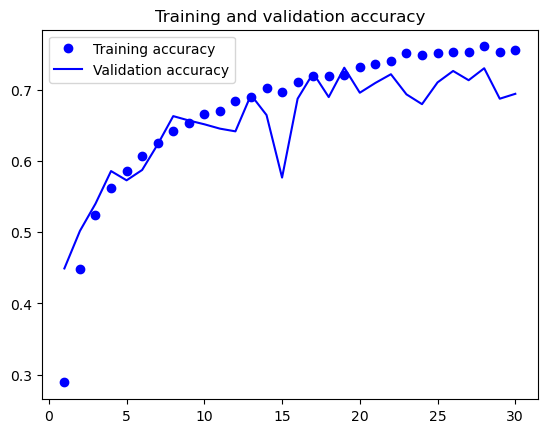

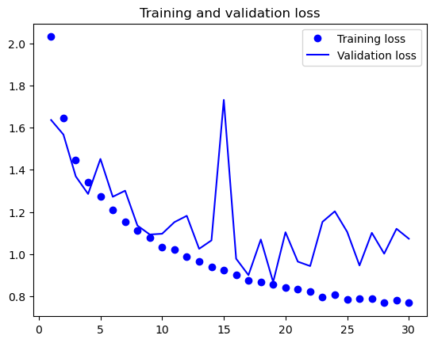

```python
import matplotlib.pyplot as plt
accuracy = history2.history["accuracy"]
val_accuracy = history2.history["val_accuracy"]
loss = history2.history["loss"]
val_loss = history2.history["val_loss"]
epochs = range(1, len(accuracy) + 1)
plt.plot(epochs, accuracy, "bo", label="Training accuracy")
plt.plot(epochs, val_accuracy, "b", label="Validation accuracy")
plt.title("Training and validation accuracy")
plt.legend()
plt.figure()
plt.plot(epochs, loss, "bo", label="Training loss")
plt.plot(epochs, val_loss, "b", label="Validation loss")
plt.title("Training and validation loss")
plt.legend()
plt.show()
```

##### better than last time, but quite weird. On validation dataset, overall the accuracy&loss go to the direction where they are supposed to go, but actually they go up then down, not a steadfast tendency. I guess this is because I "changed" data(augmentation) and reset model paramters' values, maybe interruption?

```python
test_loss, test_acc = m2.evaluate(test_data)
print(f"Test accuracy: {test_acc:.3f}")
```

```
Test accuracy: 0.701
```

##### from the test dataset, the model looks fine.

# fine-tuning

## feature extraction plus data augmentation

##### vgg, resnet, inception, mobilenet, can all be used as pre-trained CNN models. I randomly select one to see how it performs. Maybe next time I can change to another one.

```python
from tensorflow.keras.applications.resnet50 import ResNet50
conv_base =  ResNet50(
    weights="imagenet",
    include_top=False)

conv_base.trainable = False
```

```
Downloading data from https://storage.googleapis.com/tensorflow/keras-applications/resnet/resnet50_weights_tf_dim_ordering_tf_kernels_notop.h5
```

##### check how weights behave, during and after "freezing"---fix the weights of some layers, then let remaining layers to be fine-tuned

##### trainable weights before freezing

```python
conv_base.trainable = True
print("This is the number of trainable weights "
      "before freezing the conv base:", len(conv_base.trainable_weights))
```

```
This is the number of trainable weights before freezing the conv base: 212
```

##### trainable weights after freezing

```python
conv_base.trainable = False
print("This is the number of trainable weights "
      "after freezing the conv base:", len(conv_base.trainable_weights))
```

```
This is the number of trainable weights after freezing the conv base: 0
```

##### combine with data augmentation

```python
from tensorflow.keras.applications.resnet50 import preprocess_input

data_augmentation = keras.Sequential(
    [
        layers.RandomFlip("horizontal"),
        layers.RandomRotation(0.1),
        layers.RandomZoom(0.2),
        layers.RandomBrightness(factor=0.5),

    ]
)


inputs = keras.Input(shape=(224,224, 3))
x = data_augmentation(inputs)
x = keras.applications.resnet50.preprocess_input(x)
x = conv_base(x)
x = layers.Flatten()(x)
x = layers.Dense(400)(x)
x = layers.Dropout(0.5)(x)
outputs = layers.Dense(10, activation="softmax")(x)
m3 = keras.Model(inputs, outputs)
m3.compile(loss="categorical_crossentropy",
              optimizer="rmsprop",
              metrics=["accuracy"])
```

```python
callbacks = [
    keras.callbacks.ModelCheckpoint(
        filepath="feature_extraction_with_data_augmentation.keras",
        save_best_only=True,
        monitor="val_loss")
]
history3 = m3.fit(
    train_data,
    epochs=30,
    validation_data=valid_data,
    callbacks=callbacks)
```

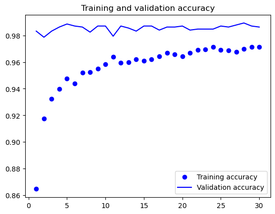

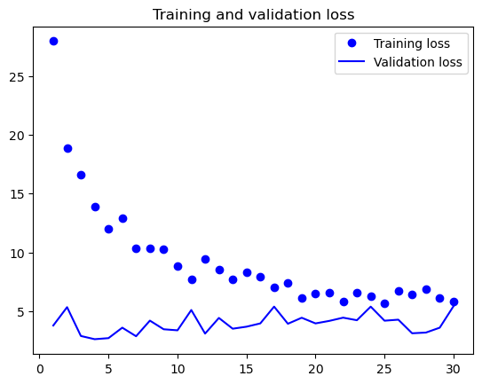

```python
import matplotlib.pyplot as plt
accuracy = history3.history["accuracy"]
val_accuracy = history3.history["val_accuracy"]
loss = history3.history["loss"]
val_loss = history3.history["val_loss"]
epochs = range(1, len(accuracy) + 1)
plt.plot(epochs, accuracy, "bo", label="Training accuracy")
plt.plot(epochs, val_accuracy, "b", label="Validation accuracy")
plt.title("Training and validation accuracy")
plt.legend()
plt.figure()
plt.plot(epochs, loss, "bo", label="Training loss")
plt.plot(epochs, val_loss, "b", label="Validation loss")
plt.title("Training and validation loss")
plt.legend()
plt.show()
```

##### for the validatin data: for accuracy, it doesn't change much, but very high at always; for loss, it doesn't change much neither, and is very low at always. Just by talking about scores, in either scenarios they behave no worse than train.

```python
test_model1 = keras.models.load_model("feature_extraction_with_data_augmentation.keras")
test_loss, test_acc = test_model1.evaluate(test_data)
print(f"Test accuracy: {test_acc:.3f}")
```

```
Test accuracy: 0.979
```

## fine tune this model

##### Here we randomly choose to inversely freeze all layers until the fourth one

```python
conv_base.trainable = True
for layer in conv_base.layers[:-4]:
    layer.trainable = False
```

```python
m3.compile(loss="categorical_crossentropy",
              optimizer=keras.optimizers.RMSprop(learning_rate=1e-5),
              metrics=["accuracy"])

callbacks = [
    keras.callbacks.ModelCheckpoint(
        filepath="fine_tuning.keras",
        save_best_only=True,
        monitor="val_loss")
]
history3_0 = m3.fit(
    train_data,
    epochs=30,
    validation_data=valid_data,
    callbacks=callbacks)
```

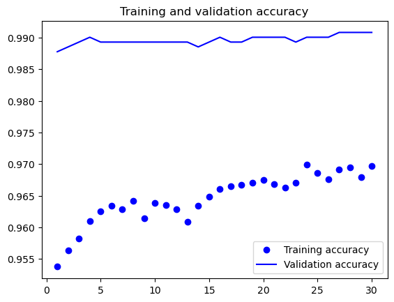

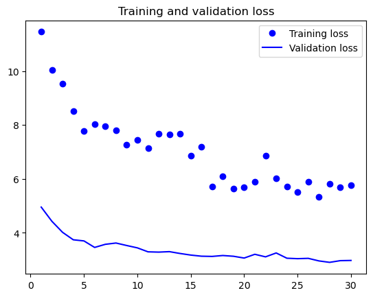

```python
import matplotlib.pyplot as plt
accuracy = history3_0.history["accuracy"]
val_accuracy = history3_0.history["val_accuracy"]
loss = history3_0.history["loss"]
val_loss = history3_0.history["val_loss"]
epochs = range(1, len(accuracy) + 1)
plt.plot(epochs, accuracy, "bo", label="Training accuracy")
plt.plot(epochs, val_accuracy, "b", label="Validation accuracy")
plt.title("Training and validation accuracy")
plt.legend()
plt.figure()
plt.plot(epochs, loss, "bo", label="Training loss")
plt.plot(epochs, val_loss, "b", label="Validation loss")
plt.title("Training and validation loss")
plt.legend()
plt.show()
```

##### for the validation dataset: for the accuracy, still, doesn't change much, but very high at always; for loss, it continues decreasing. In terms of scores, in either scenarios they behave better than train.

```python
test_model2 = keras.models.load_model("fine_tuning.keras")
test_loss, test_acc = test_model2.evaluate(test_data)
print(f"Test accuracy: {test_acc:.3f}")
```

```
Test accuracy: 0.987
```